# Research

## Research Question

Among NCDOT state-maintained roads, not including interstate roads, in Mecklenburg County, how does the rate of fatal and serious-injury crashes vary by posted speed limit?

```python
import requests
import pandas as pd
import numpy as np
import geopandas as gpd
import matplotlib.pyplot as plt
from matplotlib.patches import Patch
import seaborn as sns

pd.set_option('display.max_columns', None)
```

## API Requests

### Helper Function

Simplifies the querying process to the ArcGIS API for mapping data

```python
def query_arcgis(query_url, params, crs="EPSG:4326", batch_size=2000):


    all_records = []
    offset = 0

    while True:

        params["outSR"] = 4326
        params["resultOffset"] = offset
        params["resultRecordCount"] = batch_size

        response = requests.get(query_url, params=params, timeout=30)

        response.raise_for_status()
        data = response.json()

        if "error" in data:
            raise RuntimeError(data["error"])

        features = data.get("features", [])
        all_records.extend(features)

        print(f"Downloaded {len(all_records):,} records")

        if len(features) < batch_size:
            break

        offset += batch_size

    gdf = gpd.GeoDataFrame.from_features(all_records, crs=crs)

    return gdf
```

## Crash Data Request

```python
crashes_url = (
    "https://services.arcgis.com/NuWFvHYDMVmmxMeM/"
    "ArcGIS/rest/services/NC_FatalAndSeriousInjuryCrashes/"
    "FeatureServer/0/query"
)

crashes_params = {
    "where": "County_Nam = 'Mecklenburg'",
    "outFields": "*",
    "returnGeometry": "true",
    "f": "geojson"
}



crashes_gdf = query_arcgis(query_url=crashes_url, params=crashes_params)



print(crashes_gdf.shape)
print(crashes_gdf.crs)
crashes_gdf.head()
```

```
Downloaded 2,000 records
Downloaded 2,817 records
(2817, 34)
EPSG:4326
```

|  | geometry | FID | Crash_ID | GIS_RteTxt | GIS_Milepo | Longitude | Latitude | Source_ID | MapMethod | LOC_ERROR | Date | Time | Day_of_Wee | County_Nam | City | MPO_RPO_Na | Crash_Seve | Crash_Type | Num_Vehicl | Num_Non_Mo | Weather | Road_Condi | Light_Cond | Alcohol_Re | Speed_Rela | Unbelted_D | Motorcycle | Heavy_Truc | On_Road | … |
| --- | --- | --- | --- | --- | --- | --- | --- | --- | --- | --- | --- | --- | --- | --- | --- | --- | --- | --- | --- | --- | --- | --- | --- | --- | --- | --- | --- | --- | --- | --- |
| 0 | POINT (-80.84818 35.28373) | 16 | 106821005 | 10000077060 | 14.025 | -80.848176 | 35.283731 | 0 | RTEMP | NO ERROR | 12/25/2021. | 19:03 | Saturday | Mecklenburg | Charlotte | CHARLOTTE REGIONAL TRANSPORTATION PLANNING ORG... | A | Fixed Object | 1 | 0 | Clear | Dry | Dark - Lighted Roadway | Y | N | N | N | N | I 77 | … |
| 1 | POINT (-80.84991 35.0653) | 54 | 105066556 | 10800485060 | 30.952 | -80.849914 | 35.065300 | 0 | RTEMP | NO ERROR | 04/10/2017. | 18:10 | Monday | Mecklenburg | Pineville | CHARLOTTE REGIONAL TRANSPORTATION PLANNING ORG... | K | Overturn/Rollover | 2 | 0 | Clear | Dry | Daylight | Y | N | N | Y | N | I 485 | … |
| 2 | POINT (-80.63361 35.20882) | 60 | 105499181 | 30000051060 | 21.128 | -80.633607 | 35.208822 | 0 | RTEMP | NO ERROR | 05/22/2018. | 12:32 | Tuesday | Mecklenburg | Mint Hill | CHARLOTTE REGIONAL TRANSPORTATION PLANNING ORG... | A | Other Collision With Vehicle | 2 | 0 | Clear | Dry | Daylight | N | N | Y | N | N | NC 51 | … |
| 3 | POINT (-80.75231 35.06599) | 92 | 104685381 | 10800485060 | 25.277 | -80.752305 | 35.065995 | 0 | RTEMP | NO ERROR | 03/20/2016. | 1:58 | Sunday | Mecklenburg | Charlotte | CHARLOTTE REGIONAL TRANSPORTATION PLANNING ORG... | K | Head On | 2 | 0 | Cloudy | Dry | Dark - Roadway Not Lighted | Y | N | N | N | N | I 485 | … |
| 4 | POINT (-80.73504 35.12026) | 97 | 106312442 | 30000051060 | 11.435 | -80.735037 | 35.120257 | 0 | RTEMP | NO ERROR | 08/20/2020. | 19:06 | Thursday | Mecklenburg | Matthews | CHARLOTTE REGIONAL TRANSPORTATION PLANNING ORG... | A | Left Turn, Same Roadway | 2 | 0 | Clear | Dry | Daylight | N | Y | N | Y | N | MATTHEWS TOWNSHIP | … |

## Speed Limit Data Request

### Issue with API

The NCDOT speed-limit data was originally retrieved directly from the ArcGIS API. During the project, this API became unavailable. Because I had previously downloaded and stored the API results locally as a GeoPackage, I used that saved version for the remainder of the analysis.

The locally stored data represents the same NCDOT speed-limit data retrieved during an earlier successful API request.

```python
speed_limits_url = (
    "https://gis11.services.ncdot.gov/arcgis/rest/services/NCDOT_SpeedLimitQtr/MapServer/0/query"
)

speed_limits_params = {
    "where": (
        "MaintCntyCode IN ('090', '060', '013', '036', '049', '055') "
        "AND RouteClass IN ('2', '3', '4')"
    ),
    "outFields": "*",
    "returnGeometry": "true",
    "f": "geojson"
}

"""
speed_limits_gdf = query_arcgis(query_url=speed_limits_url, params=speed_limits_params)

print(speed_limits_gdf.shape)
print(speed_limits_gdf.crs)
speed_limits_gdf.head()
"""
```

[output not shown]

```python
speed_limits_gdf = gpd.read_file(
    "nc_speed_limits.gpkg",
    layer="speed_limits"
)

speed_limits_gdf = speed_limits_gdf[speed_limits_gdf["RouteClass"].isin(['2', '3', '4'])]

print(speed_limits_gdf.shape)
print(speed_limits_gdf.crs)
speed_limits_gdf.head()
```

```
(11210, 13)
EPSG:4326
```

|  | OBJECTID | MaintCntyCode | RouteClass | RouteNumber | RouteQualifier | RouteInventory | Direction | SpeedLimit | RouteId | BeginMp | EndMp | Shape.STLength() | geometry |
| --- | --- | --- | --- | --- | --- | --- | --- | --- | --- | --- | --- | --- | --- |
| 0 | 10568 | 013 | 3 | 24 | 0 | 0 | EB | 55 | 30000024013 | 0.000000 | 0.001163 | 6.173762 | MULTILINESTRING ((-80.59968 35.23408, -80.5996... |
| 1 | 10622 | 013 | 3 | 200 | 0 | 0 | BD | 35 | 30000200013 | 0.311958 | 0.325533 | 71.651182 | MULTILINESTRING ((-80.43717 35.2972, -80.43718... |
| 2 | 10624 | 013 | 3 | 24 | 0 | 0 | EB | 45 | 30000024013 | 2.890000 | 2.897168 | 37.865828 | MULTILINESTRING ((-80.55551 35.24918, -80.5555... |
| 3 | 10625 | 013 | 3 | 24 | 0 | 0 | EB | 45 | 30000024013 | 6.722061 | 6.854000 | 696.477572 | MULTILINESTRING ((-80.48829 35.25381, -80.4877... |
| 4 | 10626 | 013 | 2 | 29 | 0 | 4 | SB | 55 | 20400029013 | 14.034860 | 14.034951 | 0.481455 | MULTILINESTRING ((-80.69375 35.34679, -80.6937... |

```python
counties_url = (
    "https://services.arcgis.com/NuWFvHYDMVmmxMeM/"
    "arcgis/rest/services/NC_CountyBoundary/"
    "FeatureServer/1/query"
)

counties_params = {
    "where": "1=1",
    "outFields": "*",
    "returnGeometry": "true",
    "f": "geojson"
}


counties_gdf = query_arcgis(query_url=counties_url, params=counties_params)


print(counties_gdf.shape)
print(counties_gdf.crs)
counties_gdf.head()
```

```
Downloaded 100 records
(100, 40)
EPSG:4326
```

|  | geometry | OBJECTID_1 | OBJECTID_2 | OBJECTID | FIPS | Shape_Leng | Shape_Le_1 | NAME | NAME_LOCAS | DOT_DISTRI | DOT_DIVISI | DOT_COUNTY | COUNTY_100 | DOT_GROUP_ | ACRES | ABBR_5CHAR | ABBR_4CHAR | ABBR_2CHAR | Z_MEAN | Z_MIN | Z_MAX | Z_ZONE | POP1990 | POP1996 | POP2000PRJ | POP2010PRJ | BRITH94RAT | COG_NAME | COG_REGION | … |
| --- | --- | --- | --- | --- | --- | --- | --- | --- | --- | --- | --- | --- | --- | --- | --- | --- | --- | --- | --- | --- | --- | --- | --- | --- | --- | --- | --- | --- | --- | --- |
| 0 | POLYGON ((-75.90629 36.08588, -75.90663 36.085... | 1 | 1 | 1 | 29 | 680450.768094 | 680450.768094 | CAMDEN | Camden | 1 | 1 | 14 | 15 | CURR,CAMD,PASQ,PERQ | 198586 | CAMDE | CAMD | CM | 7 | 0 | 27 | 0 | 5904 | 6445 | 6687 | 7058 | 11.4 | Albemarle | R | … |
| 1 | POLYGON ((-76.69658 36.29619, -76.69673 36.296... | 2 | 2 | 2 | 73 | 444604.409222 | 444604.409222 | GATES | Gates | 1 | 1 | 36 | 37 | GATE,HERT | 221320 | GATES | GATE | GA | 28 | 0 | 81 | 0 | 9305 | 9835 | 10117 | 10774 | 13.0 | Albemarle | R | … |
| 2 | POLYGON ((-80.94812 35.49117, -80.94835 35.491... | 3 | 3 | 3 | 97 | 639632.072237 | 639632.072237 | IREDELL | Iredell | 2 | 12 | 48 | 49 | IRED,ALEX,CATA | 382705 | IREDE | IRED | IR | 901 | 667 | 1758 | 1000 | 92935 | 105957 | 112715 | 127174 | 14.6 | Centralina | F | … |
| 3 | POLYGON ((-81.30257 36.00491, -81.30285 36.004... | 4 | 4 | 4 | 193 | 718208.841742 | 718208.841742 | WILKES | Wilkes | 3 | 11 | 96 | 97 | ASHE,WILK | 484659 | WILKE | WILK | WL | 1496 | 871 | 4091 | 2500 | 59393 | 62438 | 63852 | 64906 | 12.6 | High Country | D | … |
| 4 | POLYGON ((-80.55036 35.20841, -80.55007 35.208... | 5 | 5 | 5 | 179 | 584385.109654 | 584385.109654 | UNION | Union | 3 | 10 | 89 | 90 | UNIO | 409258 | UNION | UNIO | UN | 586 | 286 | 816 | 500 | 84210 | 101507 | 111012 | 132436 | 16.5 | Centralina | F | … |

## Data Preparation

```python
crashes_gdf = crashes_gdf.to_crs("EPSG:2264")
speed_limits_gdf = speed_limits_gdf.to_crs("EPSG:2264")

meck_gdf = counties_gdf[counties_gdf["NAME"] == "MECKLENBURG"]
meck_gdf = meck_gdf.to_crs("EPSG:2264")
```

```python
print("Missing crash coordinates:")
print(crashes_gdf.geometry.isna().sum())

print("\nMissing road speed limits:")
print(speed_limits_gdf["SpeedLimit"].isna().sum())

print("\nMissing road geometries:")
print(speed_limits_gdf.geometry.isna().sum())
```

```
Missing crash coordinates:
7

Missing road speed limits:
0

Missing road geometries:
0
```

```python
crashes_gdf = crashes_gdf.dropna(subset=["geometry"])

print("Missing crash coordinates:")
print(crashes_gdf.geometry.isna().sum())
```

```
Missing crash coordinates:
0
```

### Calculate Mecklenburg County Data

Calculate crashes and speed limits within Mecklenburg County boundaries

```python
crashes_meck = gpd.sjoin(
    crashes_gdf,
    meck_gdf,
    how="inner",
    predicate="within"
)

speed_limits_meck = gpd.clip(
    speed_limits_gdf,
    meck_gdf
)
```

### County Boundary Tolerance

A small number of crashes classified by NCDOT as Mecklenburg County crashes fell slightly outside the county boundary polygon. I tested a 50-foot boundary tolerance to determine how many additional Mecklenburg-classified crashes would be retained.

```python
meck_buffer = meck_gdf.copy()
meck_buffer["geometry"] = meck_buffer.geometry.buffer(50)

# Keep crashes inside Mecklenburg OR within 50 feet of the border
crashes_meck_buffer = gpd.sjoin(
    crashes_gdf,
    meck_buffer[["geometry"]],
    how="inner",
    predicate="within"
)

print(f"Crashes strictly within Mecklenburg: {len(crashes_meck):,}")
print(f"Crashes within Mecklenburg + 50-ft tolerance: {len(crashes_meck_buffer):,}")
print(f"Additional crashes retained by buffer: "f"{len(crashes_meck_buffer) - len(crashes_meck):,}")
```

```
Crashes strictly within Mecklenburg: 2,801
Crashes within Mecklenburg + 50-ft tolerance: 2,803
Additional crashes retained by buffer: 2
```

### Attaching Crashes to Roads

Determining which distance would be best for attaching a crash to a specific road

```python
distance_tests = [25, 50, 100, 150, 250]

match_results = []

for distance in distance_tests:
    test_match = gpd.sjoin_nearest(
        crashes_meck_buffer.drop(columns=["index_right"], errors="ignore"),
        speed_limits_meck[["SpeedLimit", "RouteId", "geometry"]],
        how="left",
        max_distance=distance,
        distance_col="distance_ft"
    )

    matched_count = test_match["distance_ft"].notna().sum()
    matched_percent = matched_count / len(crashes_meck_buffer) * 100

    match_results.append({
        "Max Distance (ft)": distance,
        "Matched Crashes": matched_count,
        "Percent Matched": matched_percent
    })

distance_results = pd.DataFrame(match_results)
distance_results
```

|  | Max Distance (ft) | Matched Crashes | Percent Matched |
| --- | --- | --- | --- |
| 0 | 25 | 1219 | 43.489119 |
| 1 | 50 | 1362 | 48.590796 |
| 2 | 100 | 1457 | 51.980021 |
| 3 | 150 | 1493 | 53.264360 |
| 4 | 250 | 1570 | 56.011416 |

```python
crashes_meck_buffer = crashes_meck_buffer.drop(
    columns=["index_right"],
    errors="ignore"
)

matched = gpd.sjoin_nearest(
    crashes_meck_buffer,
    speed_limits_meck[["SpeedLimit", "RouteId", "geometry"]],
    how="left",
    max_distance=50,
    distance_col="distance_ft"
)


crashes_within_50 = matched[
    matched["distance_ft"].notna()
].copy()
```

## Data Visualization

### Building the Map Visual

All of the counties from which speed limit data was pulled from.

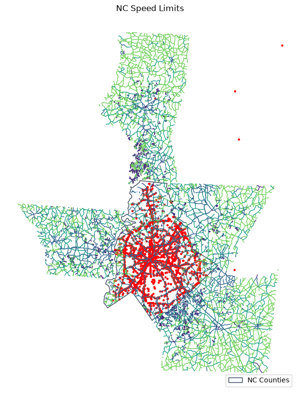

```python
fig, ax = plt.subplots(figsize=(10, 10))
meck_gdf.plot(ax=ax, facecolor="#f8fafc", edgecolor="#334155", linewidth=1.0)
speed_limits_gdf.plot(ax=ax, column="SpeedLimit", linewidth=1.0)
crashes_gdf.plot(ax=ax, markersize=5, color="red")

ax.set_title("NC Speed Limits")
ax.set_axis_off()

legend_elements = [
    Patch(facecolor='#f8fafc', edgecolor='#334155', label='NC Counties')
]
ax.legend(handles=legend_elements, loc='lower right', frameon=True)

plt.show()
```

Speed limit data is now cut off to be solely within Mecklenburg County

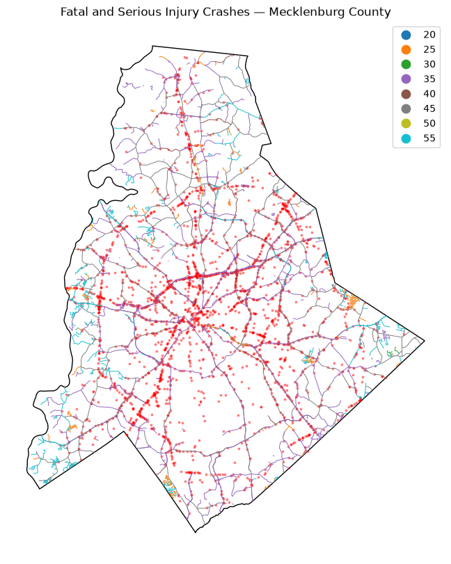

```python
fig, ax = plt.subplots(figsize=(12, 10))

meck_gdf.plot(
    ax=ax,
    facecolor="none",
    edgecolor="black",
    linewidth=1
)

speed_limits_meck.plot(
    ax=ax,
    column="SpeedLimit",
    categorical=True,
    legend=True,
    linewidth=0.7
)

crashes_meck.plot(
    ax=ax,
    markersize=3,
    alpha=0.4,
    color="red"
)



ax.set_title("Fatal and Serious Injury Crashes — Mecklenburg County")
ax.set_axis_off()

plt.show()
```

Includes the two crashes that are within the 50 foot buffer around the Mecklenburg County boundary

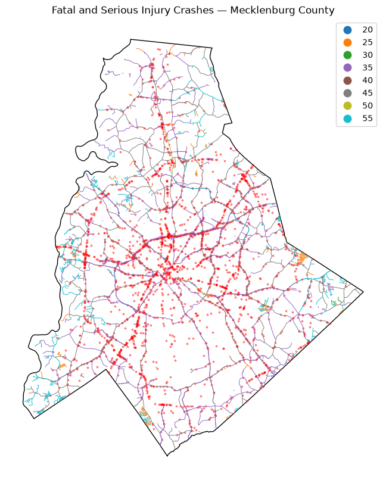

```python
fig, ax = plt.subplots(figsize=(12, 10))

meck_gdf.plot(
    ax=ax,
    facecolor="none",
    edgecolor="black",
    linewidth=1
)

speed_limits_meck.plot(
    ax=ax,
    column="SpeedLimit",
    categorical=True,
    legend=True,
    linewidth=0.7
)

crashes_meck_buffer.plot(
    ax=ax,
    markersize=3,
    alpha=0.4,
    color="red"
)



ax.set_title("Fatal and Serious Injury Crashes — Mecklenburg County")
ax.set_axis_off()

plt.show()
```

Only uses crashes that are within 50 feet of a road

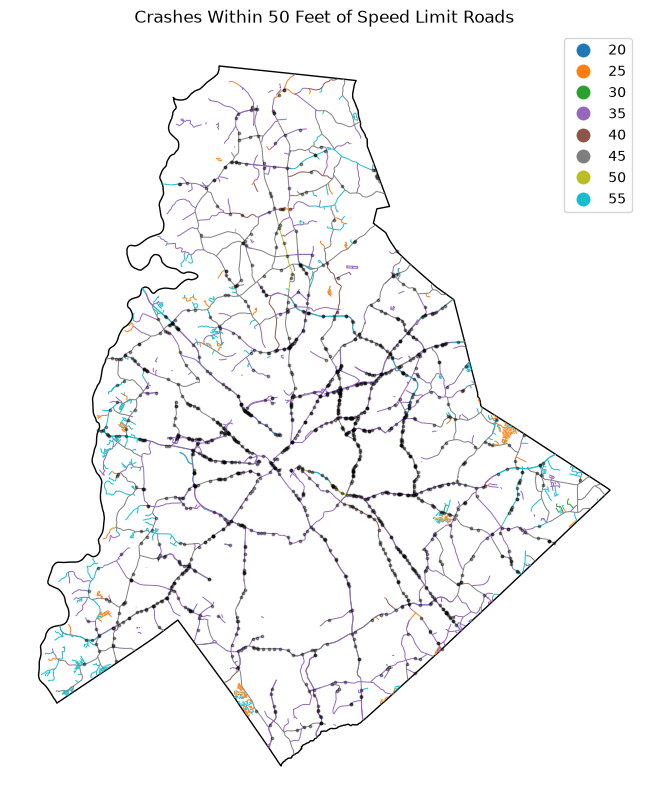

```python
fig, ax = plt.subplots(figsize=(14, 10))

meck_gdf.plot(
    ax=ax,
    facecolor="none",
    edgecolor="black",
    linewidth=1
)

speed_limits_meck.plot(
    ax=ax,
    column="SpeedLimit",
    categorical=True,
    legend=True,
    linewidth=0.7
)

crashes_within_50.plot(
    ax=ax,
    markersize=3,
    alpha=0.4,
    color="black",
    zorder=2
)

ax.set_title("Crashes Within 50 Feet of Speed Limit Roads")
ax.set_axis_off()

plt.show()
```

Same visual but with better color scheme and legend for easier understanding

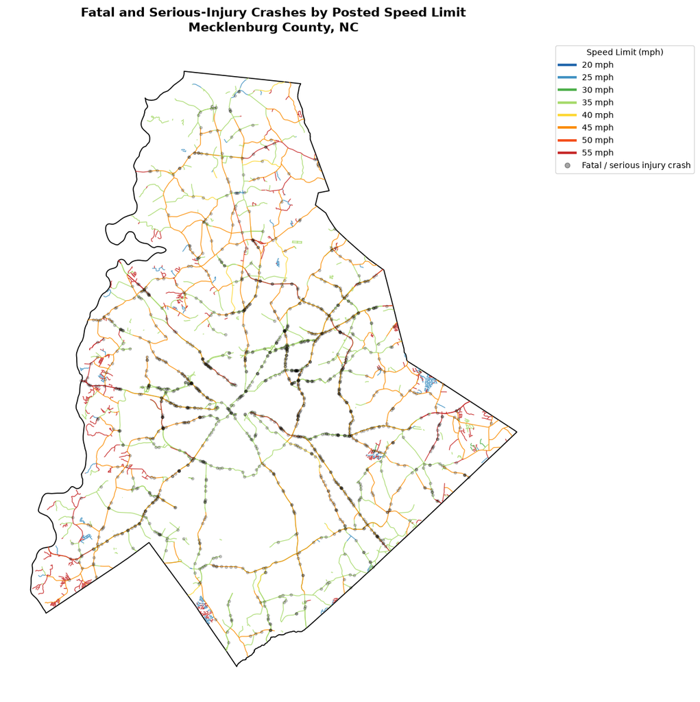

```python
import matplotlib.pyplot as plt
from matplotlib.lines import Line2D

# Ordered colors:
# lower speeds = cooler colors
# higher speeds = warmer colors
speed_colors = {
    20: "#2166ac",
    25: "#4393c3",
    30: "#4daf4a",
    35: "#a6d96a",
    40: "#fdd835",
    45: "#fb8c00",
    50: "#f4511e",
    55: "#c62828"
}

fig, ax = plt.subplots(figsize=(12, 12))

# County boundary
meck_gdf.plot(
    ax=ax,
    facecolor="white",
    edgecolor="black",
    linewidth=1.2,
    zorder=1
)

# Plot roads by speed limit
for speed, color in speed_colors.items():
    roads = speed_limits_meck[
        speed_limits_meck["SpeedLimit"] == speed
    ]

    roads.plot(
        ax=ax,
        color=color,
        linewidth=0.9,
        alpha=0.9,
        zorder=2
    )

# Plot crashes
crashes_within_50.plot(
    ax=ax,
    color="black",
    markersize=10,
    alpha=0.20,
    zorder=3
)

# -------------------------
# Custom legend
# -------------------------

legend_handles = []

# Speed limit legend items
for speed, color in speed_colors.items():
    legend_handles.append(
        Line2D(
            [0],
            [0],
            color=color,
            linewidth=3,
            label=f"{speed} mph"
        )
    )

# Crash legend item
legend_handles.append(
    Line2D(
        [0],
        [0],
        marker="o",
        color="none",
        markerfacecolor="black",
        markeredgecolor="black",
        markersize=6,
        alpha=0.35,
        linestyle="None",
        label="Fatal / serious injury crash"
    )
)

ax.legend(
    handles=legend_handles,
    title="Speed Limit (mph)",
    loc="upper left",
    bbox_to_anchor=(1.02, 1),
    frameon=True
)

ax.set_title(
    "Fatal and Serious-Injury Crashes by Posted Speed Limit\n"
    "Mecklenburg County, NC",
    fontsize=15,
    fontweight="bold",
    pad=12
)

ax.set_axis_off()

plt.tight_layout()
plt.show()
```

### Building the Bar Plot Visual

Calculating the number of crashes in every speed limit category

```
SpeedLimit
20.0      1
25.0      7
30.0      3
35.0    688
40.0     37
45.0    521
50.0     16
55.0     89
dtype: int64
```

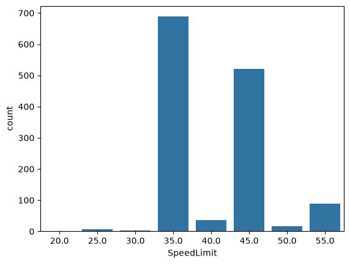

```python
crashes_by_speed = crashes_within_50.groupby("SpeedLimit").size()

print(crashes_by_speed)
sns.countplot(data=crashes_within_50, x="SpeedLimit")
```

Calculating the length of roadway a speed limit has in Mecklenburg County in miles

```python
# Length of each road segment in miles
speed_limits_meck["length_miles"] = (
    speed_limits_meck.geometry.length / 5280
)

# Total road miles for each speed limit
miles_by_speed = (
    speed_limits_meck
    .groupby("SpeedLimit")["length_miles"]
    .sum()
    .sort_index()
)

print(miles_by_speed)
```

```
SpeedLimit
20      0.252165
25     48.724923
30      2.638976
35    472.509801
40     20.652262
45    320.928681
50      6.163768
55    159.955570
Name: length_miles, dtype: float64
```

Calculate the ratio of crash rate per mile for every speed limit to normalize the data

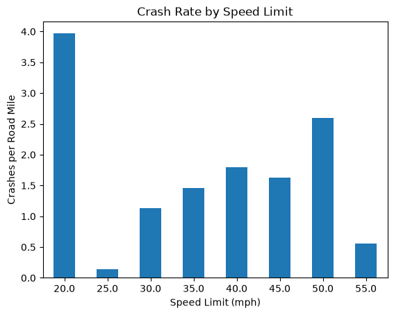

```python
crash_rate = crashes_by_speed / miles_by_speed

crash_rate.plot(kind="bar")

plt.xlabel("Speed Limit (mph)")
plt.ylabel("Crashes per Road Mile")
plt.title("Crash Rate by Speed Limit")

plt.xticks(rotation=0)
plt.show()
```

```python
results = pd.DataFrame({
    "crashes": crashes_by_speed,
    "road_miles": miles_by_speed
})

results["crashes_per_road_mile"] = (
    results["crashes"] / results["road_miles"]
)

print(results)
```

```
            crashes  road_miles  crashes_per_road_mile
SpeedLimit
20.0              1    0.252165               3.965664
25.0              7   48.724923               0.143664
30.0              3    2.638976               1.136805
35.0            688  472.509801               1.456054
40.0             37   20.652262               1.791571
45.0            521  320.928681               1.623414
50.0             16    6.163768               2.595815
55.0             89  159.955570               0.556405
```

Add a color scheme matching the map visual

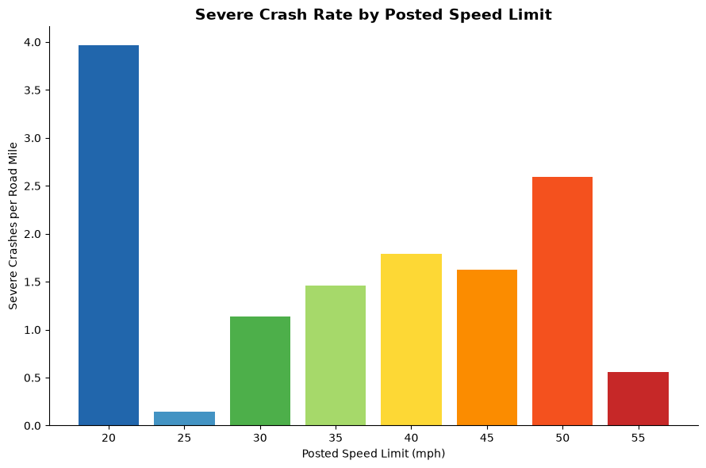

```python
bar_colors = [
    speed_colors[speed]
    for speed in crash_rate.index
]

fig, ax = plt.subplots(figsize=(9, 6))

ax.bar(
    crash_rate.index.astype(int).astype(str),
    crash_rate.values,
    color=bar_colors
)

ax.set_xlabel("Posted Speed Limit (mph)")
ax.set_ylabel("Severe Crashes per Road Mile")
ax.set_title(
    "Severe Crash Rate by Posted Speed Limit",
    fontsize=14,
    fontweight="bold"
)

ax.spines["top"].set_visible(False)
ax.spines["right"].set_visible(False)

plt.tight_layout()
plt.show()
```

### Only 20 mph Severe Crash

Discovering the reason behind the 20 mph crash, which is that a pdestrain was hit.

```python
crashes_within_50[crashes_within_50["SpeedLimit"] == 20]
```

|  | geometry | FID | Crash_ID | GIS_RteTxt | GIS_Milepo | Longitude | Latitude | Source_ID | MapMethod | LOC_ERROR | Date | Time | Day_of_Wee | County_Nam | City | MPO_RPO_Na | Crash_Seve | Crash_Type | Num_Vehicl | Num_Non_Mo | Weather | Road_Condi | Light_Cond | Alcohol_Re | Speed_Rela | Unbelted_D | Motorcycle | Heavy_Truc | On_Road | … |
| --- | --- | --- | --- | --- | --- | --- | --- | --- | --- | --- | --- | --- | --- | --- | --- | --- | --- | --- | --- | --- | --- | --- | --- | --- | --- | --- | --- | --- | --- | --- |
| 1957 | POINT (1449694.569 641324.25) | 39886 | 106606822 | 30000115060 | 13.987 | -80.849003 | 35.498067 | 1 | XY |  | 06/17/2021. | 13:03 | Thursday | Mecklenburg | Davidson | CHARLOTTE REGIONAL TRANSPORTATION PLANNING ORG... | K | Pedestrian | 1 | 1 | Clear | Dry | Daylight | N | N | N | N | N | NC 115 | … |